# betting_odds

```python
import pandas as pd
import numpy as np
import seaborn as sns
import matplotlib.pyplot as plt
import sklearn
from sklearn.model_selection import train_test_split
from sklearn.linear_model import LogisticRegression
from sklearn.preprocessing import StandardScaler
from sklearn import metrics
from sklearn import tree

lr = LogisticRegression()

pd.set_option('display.max_rows', 500)
pd.set_option('display.max_columns', 500)
pd.set_option('display.width', 1000)
```

```python
# import csv
match = pd.read_csv("../Datasets/match.csv")
```

```python
# drop unnecessary columns
del match['date']

for i in range(11):
    del match['home_player_' + str(i + 1)]
    del match['away_player_' + str(i + 1)]
```

```python
odds_columns = match.columns[9:]
agent_list = pd.array([x[:-1] for x in odds_columns]).unique()
```

```python
match = match.dropna(thresh = len(odds_columns)).reset_index(drop = True) # drop rows with no odds data
```

# Computing the Implied Win Rates

We compute the implied probability with the following formula: $$P(x) = \frac{1}{\frac{1}{n} \sum_{n=1}^{n} x_n}$$

where $n$ is number of agencies and $x_n$ is the odd (Home/Away/Draw)

Noted that $P(Home) + P(Away) + P(Draw) \neq 1$, this is because of the betting agencies' margin, to adjust, we use the following formula:
$$P(x)_{adjusted} = \frac{P(x)}{P(Home) + P(Away) + P(Draw)}$$

```python
odds = match[odds_columns].copy()
```

```python
for bet in ["H", "D", "A"]:
    agent_bet = [agent + bet for agent in agent_list]
    odds['mean|' + bet] = odds[agent_bet].mean(skipna = True, axis = 1)

    for i in agent_bet:
        odds[i] = odds[i].fillna(odds['mean|' + bet]) # fill na with mean
```

```python
col = []
for bet in ["H", "D", "A"]:
    agent_bet = [agent + bet for agent in agent_list]
    agent_bet.append("mean|" + str(bet))
    col += agent_bet
odds = odds[col]
```

```python
for agent in agent_list:
    agent_bet = [agent + bet for bet in ["H", "D", "A"]]
    odds[agent + "|implied_home_win_rate"] = odds[agent_bet[0]].apply(lambda x: 1/x)
    odds[agent + "|implied_away_win_rate"] = odds[agent_bet[1]].apply(lambda x: 1/x)
    odds[agent + "|implied_draw_rate"] = odds[agent_bet[2]].apply(lambda x: 1/x)
    odds[agent + "|implied_total"] = odds[agent + "|implied_home_win_rate"] + odds[agent + "|implied_away_win_rate"] + odds[agent + "|implied_draw_rate"]

    # adjust the implied win rate
    odds[agent + "|adjusted_implied_home_win_rate"] = odds[agent + "|implied_home_win_rate"] / odds[agent + "|implied_total"]
    odds[agent + "|adjusted_implied_away_win_rate"] = odds[agent + "|implied_away_win_rate"] / odds[agent + "|implied_total"]
    odds[agent + "|adjusted_implied_draw_rate"] = odds[agent + "|implied_draw_rate"] / odds[agent + "|implied_total"]


odds["mean|implied_home_win_rate"] = odds["mean|H"].apply(lambda x : 1/x)
odds["mean|implied_away_win_rate"] = odds["mean|A"].apply(lambda x : 1/x)
odds["mean|implied_draw_rate"] = odds["mean|D"].apply(lambda x : 1/x)
odds["mean|implied_total"] = odds["mean|implied_home_win_rate"] + odds["mean|implied_away_win_rate"] + odds["mean|implied_draw_rate"]

odds["mean|adjusted_implied_home_win_rate"] = odds["mean|implied_home_win_rate"] / odds["mean|implied_total"]
odds["mean|adjusted_implied_away_win_rate"] = odds["mean|implied_away_win_rate"] / odds["mean|implied_total"]
odds["mean|adjusted_implied_draw_rate"] = odds["mean|implied_draw_rate"] / odds["mean|implied_total"]
```

```python
odds
```

|  | B365H | BWH | IWH | LBH | PSH | WHH | SJH | VCH | GBH | BSH | mean\|H | B365D | BWD | IWD | LBD | PSD | WHD | SJD | VCD | GBD | BSD | mean\|D | B365A | BWA | IWA | LBA | PSA | WHA | SJA | … |
| --- | --- | --- | --- | --- | --- | --- | --- | --- | --- | --- | --- | --- | --- | --- | --- | --- | --- | --- | --- | --- | --- | --- | --- | --- | --- | --- | --- | --- | --- | --- |
| 0 | 1.73 | 1.75 | 1.85 | 1.80 | 1.765556 | 1.70 | 1.900000 | 1.65 | 1.780000 | 1.730000 | 1.765556 | 3.40 | 3.35 | 3.2 | 3.30 | 3.322222 | 3.30 | 3.300000 | 3.40 | 3.250000 | 3.400000 | 3.322222 | 5.00 | 4.20 | 3.50 | 3.75 | 4.164444 | 4.33 | 4.000000 | … |
| 1 | 1.95 | 1.80 | 1.90 | 1.90 | 1.898889 | 1.83 | 1.950000 | 2.00 | 1.850000 | 1.910000 | 1.898889 | 3.20 | 3.30 | 3.2 | 3.20 | 3.250000 | 3.30 | 3.300000 | 3.25 | 3.250000 | 3.250000 | 3.250000 | 3.60 | 3.95 | 3.50 | 3.50 | 3.616667 | 3.60 | 3.800000 | … |
| 2 | 2.38 | 2.40 | 2.60 | 2.50 | 2.462222 | 2.50 | 2.630000 | 2.35 | 2.500000 | 2.300000 | 2.462222 | 3.30 | 3.30 | 3.1 | 3.20 | 3.233333 | 3.25 | 3.300000 | 3.25 | 3.200000 | 3.200000 | 3.233333 | 2.75 | 2.55 | 2.30 | 2.50 | 2.544444 | 2.40 | 2.500000 | … |
| 3 | 1.44 | 1.40 | 1.40 | 1.44 | 1.438889 | 1.44 | 1.440000 | 1.45 | 1.500000 | 1.440000 | 1.438889 | 3.75 | 4.00 | 3.9 | 3.60 | 3.805556 | 3.75 | 4.000000 | 3.75 | 3.750000 | 3.750000 | 3.805556 | 7.50 | 6.80 | 6.00 | 6.50 | 6.533333 | 6.00 | 7.500000 | … |
| 4 | 5.00 | 5.00 | 4.00 | 4.00 | 4.494444 | 4.20 | 4.500000 | 4.50 | 4.500000 | 4.750000 | 4.494444 | 3.50 | 3.50 | 3.3 | 3.40 | 3.422222 | 3.40 | 3.500000 | 3.40 | 3.500000 | 3.300000 | 3.422222 | 1.65 | 1.60 | 1.70 | 1.72 | 1.674444 | 1.70 | 1.730000 | … |
| ... | ... | ... | ... | ... | ... | ... | ... | ... | ... | ... | ... | ... | ... | ... | ... | ... | ... | ... | ... | ... | ... | ... | ... | ... | ... | ... | ... | ... | ... | … |
| 22518 | 1.57 | 1.57 | 1.65 | 1.57 | 1.580000 | 1.62 | 1.590000 | 1.57 | 1.590000 | 1.590000 | 1.590000 | 3.80 | 4.00 | 3.7 | 3.75 | 4.050000 | 3.30 | 3.800000 | 4.00 | 3.800000 | 3.800000 | 3.800000 | 6.50 | 6.50 | 4.90 | 6.50 | 7.060000 | 7.00 | 6.494286 | … |
| 22519 | 2.25 | 2.35 | 2.20 | 2.25 | 2.360000 | 2.38 | 2.298571 | 2.30 | 2.298571 | 2.298571 | 2.298571 | 3.25 | 3.10 | 3.2 | 3.20 | 3.360000 | 3.10 | 3.230000 | 3.40 | 3.230000 | 3.230000 | 3.230000 | 3.40 | 3.10 | 3.20 | 3.25 | 3.360000 | 3.10 | 3.258571 | … |
| 22520 | 1.53 | 1.55 | 1.60 | 1.50 | 1.550000 | 1.57 | 1.550000 | 1.55 | 1.550000 | 1.550000 | 1.550000 | 4.00 | 4.00 | 3.7 | 4.00 | 4.310000 | 3.50 | 3.958571 | 4.20 | 3.958571 | 3.958571 | 3.958571 | 7.00 | 6.50 | 5.40 | 6.50 | 6.950000 | 7.00 | 6.621429 | … |
| 22521 | 2.30 | 2.35 | 2.40 | 2.30 | 2.340000 | 2.40 | 2.341429 | 2.30 | 2.341429 | 2.341429 | 2.341429 | 3.25 | 3.25 | 3.3 | 3.20 | 3.400000 | 3.10 | 3.271429 | 3.40 | 3.271429 | 3.271429 | 3.271429 | 3.25 | 3.00 | 2.75 | 3.10 | 3.350000 | 3.10 | 3.121429 | … |
| 22522 | 2.20 | 2.25 | 2.30 | 2.10 | 2.200000 | 2.20 | 2.207143 | 2.20 | 2.207143 | 2.207143 | 2.207143 | 3.40 | 3.50 | 3.3 | 3.40 | 3.610000 | 3.40 | 3.458571 | 3.60 | 3.458571 | 3.458571 | 3.458571 | 3.20 | 3.20 | 2.90 | 3.30 | 3.460000 | 3.20 | 3.251429 | … |

22523 rows × 110 columns

```python
mean = odds[['mean|adjusted_implied_home_win_rate', 'mean|adjusted_implied_away_win_rate', 'mean|adjusted_implied_draw_rate']]
```

## Distribution of the win rates

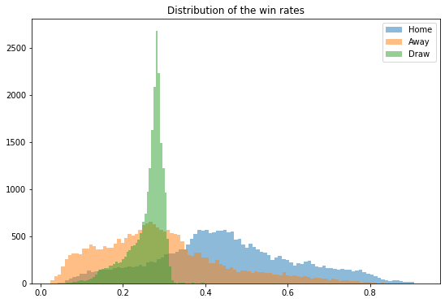

```python
plt.figure(figsize=(9,6))
_ = plt.hist(mean['mean|adjusted_implied_home_win_rate'], alpha = 0.5, bins = 100, label = "Home")
_ = plt.hist(mean['mean|adjusted_implied_away_win_rate'], alpha = 0.5, bins = 100, label = "Away")
_ = plt.hist(mean['mean|adjusted_implied_draw_rate'], alpha = 0.5, bins = 100, label = "Draw")
plt.title("Distribution of the win rates")
plt.legend(loc = "best")
```

## Correlation between win rates

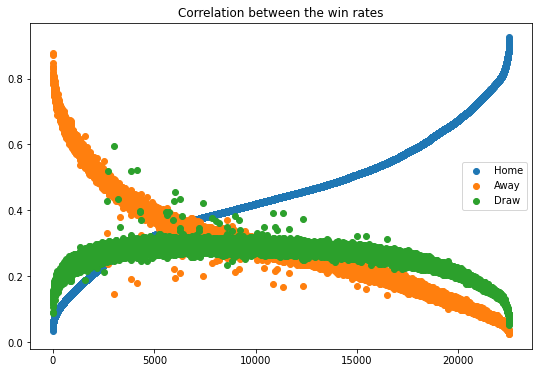

```python
temp = mean.sort_values('mean|adjusted_implied_home_win_rate').reset_index(drop=True)
plt.figure(figsize=(9,6))
plt.scatter(temp.index, temp['mean|adjusted_implied_home_win_rate'], label = "Home")
plt.scatter(temp.index, temp['mean|adjusted_implied_away_win_rate'], label = "Away")
plt.scatter(temp.index, temp['mean|adjusted_implied_draw_rate'], label = "Draw")
plt.title("Correlation between the win rates")
plt.legend(loc = "best")
```

**Some obsercations here:**

- the implied probability shows that the market is often more confident in the home team
- people place that bets more certainly when they are confident in the home team
- people are somehow confused between away or draw when they are not really confident in the home team
- there is certain threshold for the draw rate

# Computing Match results

```python
# match results
match = pd.merge(match[match.columns[:9]], mean, left_index = True, right_index = True)
match["result"] = match[['home_team_goal', 'away_team_goal']].apply(lambda x: 1 if x['home_team_goal'] > x['away_team_goal'] else (-1 if x['home_team_goal'] < x['away_team_goal'] else 0), axis = 1)
```

## Distributions of match results

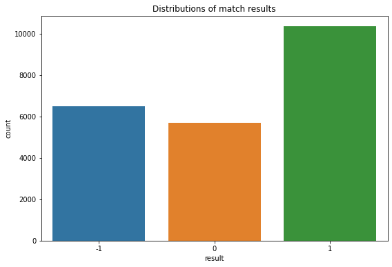

```python
plt.figure(figsize=(9,6))
sns.countplot(x="result", data = match)
plt.title("Distributions of match results")
```

```python
match.result.value_counts(normalize=True)
```

```
 1    0.459264
-1    0.288194
 0    0.252542
Name: result, dtype: float64
```

**Some observations here:**

- Home win rate is obviously higher
- Away win rate is only slightly higher than draw rate, this is somehow contradict to what the implied probability tells us - the probability shows certain threshold for draw rate but not for away win rate, suggesting that people is somewhat bad at betting at draws

# What if we directly use the implied probability model

Here we try to use the Monte Carlo method to find how accurate the agencies' implied rates is when comparing to wild guessing

```python
rand_result = match.copy()
```

```python
repeat = 1000
```

```python
rand_ls = []
for i in range(repeat):
    rand_result['rand'] = [np.random.randint(low = -1, high = 1) for k in rand_result.index]
    rand_ls.append(metrics.accuracy_score(rand_result['result'], rand_result['rand']))
print("Accuracy Score: " + str(np.array(rand_ls).mean()))
```

```
Accuracy Score: 0.2702513430715269
```

## Implied Probability

```python
implied_ls = []
for i in range(repeat):
    rand_result['prob'] = rand_result[['mean|adjusted_implied_home_win_rate', 'mean|adjusted_implied_away_win_rate', 'mean|adjusted_implied_draw_rate']].apply(lambda x: np.random.choice([1, -1, 0], p=[x['mean|adjusted_implied_home_win_rate'], x['mean|adjusted_implied_away_win_rate'], x['mean|adjusted_implied_draw_rate']]) , axis = 1)
    rand_ls.append(metrics.accuracy_score(rand_result['result'], rand_result['prob']))
print("Accuracy Score: " + str(np.array(rand_ls).mean()))
```

```
Accuracy Score: 0.38199017300833216
```

# Building more accurate models

```python
df = match[["mean|adjusted_implied_home_win_rate", "mean|adjusted_implied_away_win_rate", "mean|adjusted_implied_draw_rate", "result"]]
train_x, test_x, train_y, test_y = train_test_split(df[["mean|adjusted_implied_home_win_rate", "mean|adjusted_implied_away_win_rate", "mean|adjusted_implied_draw_rate"]], df[["result"]], test_size = 0.3)
```

```python
corr = df.corr()
```

## Correlation between implied probabilities and results

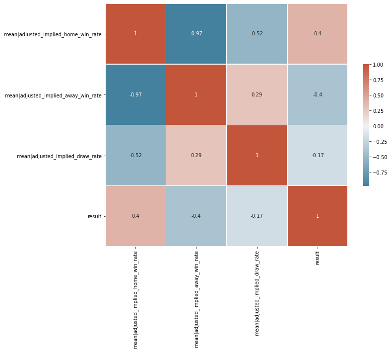

```python
f, ax = plt.subplots(figsize=(11, 9))
mask = np.triu(np.ones_like(corr, dtype=bool))
cmap = sns.diverging_palette(230, 20, as_cmap=True)
sns.heatmap(corr, cmap=cmap, center=0,
            square=True, linewidths=.5, cbar_kws={"shrink": .5}, annot = True)
```

**Some observations here:**

- implied home win rate and away win rate have somewhat strong correlations with the results
- draw rate does not have much say here
  - negative correlation to the results suggesting that when draw rate is high, the home team is less likely to win, which is same as our expectations above
  - this makes our models below bad at predicting draws as well

## Logistic Regression

```python
lr.fit(train_x, train_y)
print(lr.intercept_, lr.coef_)
```

```
[ 0.04861505 -0.01297336 -0.03564169] [[-1.65005221  1.7643677  -0.07967709]
 [-0.61524273 -0.80978717  1.42323337]
 [ 2.26529494 -0.95458053 -1.34355628]]
```

```python
predictions = lr.predict(test_x)
```

### Accuracy Score

```python
score = lr.score(test_x, test_y)
print("Accuracy Score: " + str(score))
```

```
Accuracy Score: 0.5323368358739086
```

```python
labels = [-1, 0, 1]
cm = metrics.confusion_matrix(test_y, predictions, labels = labels)
print(cm)
```

```
[[ 926    0 1021]
 [ 481    1 1171]
 [ 484    3 2670]]
```

### Confusion Matrix

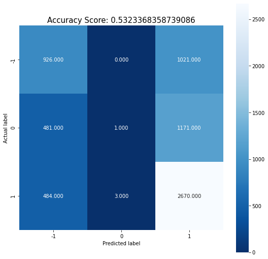

```python
plt.figure(figsize=(9,9))
sns.heatmap(cm, annot=True, fmt=".3f", square = True, cmap = 'Blues_r');
plt.ylabel('Actual label');
plt.xlabel('Predicted label');
plt.xticks(ticks = [0.5,1.5,2.5], labels = labels)
plt.yticks(ticks = [0.5,1.5,2.5], labels = labels)
all_sample_title = 'Accuracy Score: {0}'.format(score)
plt.title(all_sample_title, size = 15);
```

**Some observations here:**

- our model is bad at predicting draws
- but the results are much accurate than wild guessing or simply applying the implied probability

## Decision Tree

```python
clf = tree.DecisionTreeClassifier(max_depth = 4)
clf = clf.fit(train_x, train_y)
```

```python
predictions = clf.predict(test_x)
```

```python
score = metrics.accuracy_score(test_y, predictions)
print(score)
```

```
0.5333727985792511
```

```python
feature_cols = ["H|rate", "D|rate", "A|rate"]
class_names = ["-1", "0", "1"]
```

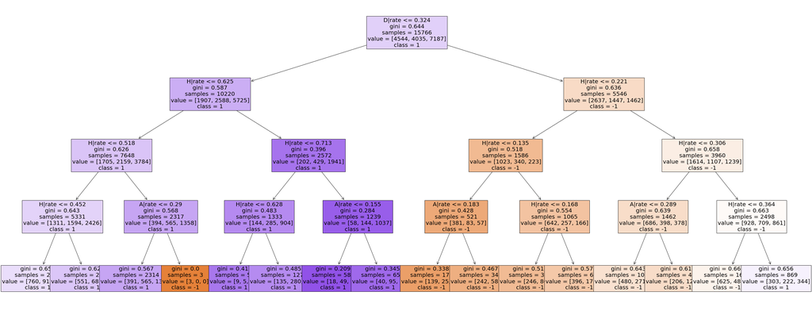

```python
fig = plt.figure(figsize=(50,20))
_ = tree.plot_tree(clf,
                   feature_names=feature_cols,
                   class_names=class_names,
                   filled=True, fontsize = 20)
```

### Accuracy Score (Monte Carlo)

```python
tree_ls = []
for x in range(repeat):
    clf = tree.DecisionTreeClassifier(max_depth = 4)
    clf = clf.fit(train_x, train_y)
    predictions = clf.predict(test_x)
    tree_ls.append(metrics.accuracy_score(test_y, predictions))
print("Accuracy Score: " + str(np.array(tree_ls).mean()))
```

```
Accuracy Score: 0.5333727985792509
```

**Some observations here:**

- our model is bad at predicting draws
- but the results are much accurate than wild guessing or simply applying the implied probability